# Practical ML Project

Amal

February 15, 2019

## 1. Objective

Using devices such as Jawbone Up, Nike FuelBand, and Fitbit it is now possible to collect a large amount of data about personal activity relatively inexpensively. These type of devices are part of the quantified self movement - a group of enthusiasts who take measurements about themselves regularly to improve their health, to find patterns in their behavior, or because they are tech geeks. One thing that people regularly do is quantify how much of a particular activity they do, but they rarely quantify how well they do it.

In this project, your goal will be to use data from accelerometers on the belt, forearm, arm, and dumbell of 6 participants. They were asked to perform barbell lifts correctly and incorrectly in 5 different ways.

## 2. Data Loading and Processing

#### 2.1. Loading necessary R Libraries

```r
library(caret)
library(rpart)
```

```r
library(rpart.plot)
library(randomForest)
library(corrplot)
library(RColorBrewer)
library(rattle)
```

#### 2.2. Downloading and Reading Data

```r
trainUrl <-"https://d396qusza40orc.cloudfront.net/predmachlearn/pml-training.csv"
testUrl <- "https://d396qusza40orc.cloudfront.net/predmachlearn/pml-testing.csv"
trainFile <- "./data/pml-training.csv"
testFile  <- "./data/pml-testing.csv"
if (!file.exists("./data")) {
  dir.create("./data")
}
if (!file.exists(trainFile)) {
  download.file(trainUrl, destfile=trainFile)
}
if (!file.exists(testFile)) {
  download.file(testUrl, destfile=testFile)
}

trainData <- read.csv(trainFile, header=TRUE)
testData <- read.csv(testFile, header=TRUE)
str(trainData)
```

```
## 'data.frame':    19622 obs. of  160 variables:
##  $ X                       : int  1 2 3 4 5 6 7 8 9 10 ...
##  $ user_name               : Factor w/ 6 levels "adelmo","carlitos",..: 2 2 2 2 2 2 2 2 2 2 ...
##  $ raw_timestamp_part_1    : int  1323084231 1323084231 1323084231 1323084232 1323084232 1323084232 1323084232 1323084232 1323084232 1323084232 ...
##  $ raw_timestamp_part_2    : int  788290 808298 820366 120339 196328 304277 368296 440390 484323 484434 ...
##  $ cvtd_timestamp          : Factor w/ 20 levels "02/12/2011 13:32",..: 9 9 9 9 9 9 9 9 9 9 ...
##  $ new_window              : Factor w/ 2 levels "no","yes": 1 1 1 1 1 1 1 1 1 1 ...
##  $ num_window              : int  11 11 11 12 12 12 12 12 12 12 ...
##  $ roll_belt               : num  1.41 1.41 1.42 1.48 1.48 1.45 1.42 1.42 1.43 1.45 ...
##  $ pitch_belt              : num  8.07 8.07 8.07 8.05 8.07 8.06 8.09 8.13 8.16 8.17 ...
##  $ yaw_belt                : num  -94.4 -94.4 -94.4 -94.4 -94.4 -94.4 -94.4 -94.4 -94.4 -94.4 ...
##  $ total_accel_belt        : int  3 3 3 3 3 3 3 3 3 3 ...
##  $ kurtosis_roll_belt      : Factor w/ 397 levels "","-0.016850",..: 1 1 1 1 1 1 1 1 1 1 ...
##  $ kurtosis_picth_belt     : Factor w/ 317 levels "","-0.021887",..: 1 1 1 1 1 1 1 1 1 1 ...
##  $ kurtosis_yaw_belt       : Factor w/ 2 levels "","#DIV/0!": 1 1 1 1 1 1 1 1 1 1 ...
```

[output cut: 86 more lines]

```r
str(testData)
```

```
## 'data.frame':    20 obs. of  160 variables:
##  $ X                       : int  1 2 3 4 5 6 7 8 9 10 ...
##  $ user_name               : Factor w/ 6 levels "adelmo","carlitos",..: 6 5 5 1 4 5 5 5 2 3 ...
##  $ raw_timestamp_part_1    : int  1323095002 1322673067 1322673075 1322832789 1322489635 1322673149 1322673128 1322673076 1323084240 1322837822 ...
##  $ raw_timestamp_part_2    : int  868349 778725 342967 560311 814776 510661 766645 54671 916313 384285 ...
##  $ cvtd_timestamp          : Factor w/ 11 levels "02/12/2011 13:33",..: 5 10 10 1 6 11 11 10 3 2 ...
##  $ new_window              : Factor w/ 1 level "no": 1 1 1 1 1 1 1 1 1 1 ...
##  $ num_window              : int  74 431 439 194 235 504 485 440 323 664 ...
##  $ roll_belt               : num  123 1.02 0.87 125 1.35 -5.92 1.2 0.43 0.93 114 ...
##  $ pitch_belt              : num  27 4.87 1.82 -41.6 3.33 1.59 4.44 4.15 6.72 22.4 ...
##  $ yaw_belt                : num  -4.75 -88.9 -88.5 162 -88.6 -87.7 -87.3 -88.5 -93.7 -13.1 ...
##  $ total_accel_belt        : int  20 4 5 17 3 4 4 4 4 18 ...
##  $ kurtosis_roll_belt      : logi  NA NA NA NA NA NA ...
##  $ kurtosis_picth_belt     : logi  NA NA NA NA NA NA ...
##  $ kurtosis_yaw_belt       : logi  NA NA NA NA NA NA ...
```

[output cut: 86 more lines]

#### 2.3. Data Pre-processing

The training data set consists of 19,622 observations on 160 columns, while the testing data set contains 20 observations and 160 variables. The “classe” variable in the training set is the outcome to predict.

We can observe that many columns in the data have NA/blank values on almost every observation. So we will remove observations having greater than 90% NA/blank, because they will not produce any information. Also, the first seven columns give and attributes which will be irrelevant to the model. So, we remove it from training and test data.

```r
colToRemove <- which(colSums(is.na(trainData)|trainData=="")>0.9*dim(trainData)[1])
trainDataClean <- trainData[,-colToRemove]
trainDataClean <- trainDataClean[,-c(1:7)]
dim(trainDataClean)
```

```
## [1] 19622    53
```

```r
testDataClean <- testData[,-colToRemove]
testDataClean <- testDataClean[,-c(1:7)]
dim(testDataClean)
```

```
## [1] 20 53
```

After data pre-processing, the new data set has reduced to 53 columns.

## 3. Data Modelling

#### 3.1. Creating training and validation data set

Using 70% and 30% split

```r
set.seed(007)
spltData <- createDataPartition(trainDataClean$classe, p = 0.7, list = FALSE)
trainDataFinal <- trainDataClean[spltData, ]
valDataFinal <- trainDataClean[-spltData, ]
dim(trainDataFinal)
```

```
## [1] 13737    53
```

```r
dim(valDataFinal)
```

```
## [1] 5885   53
```

We are trying Classification Tree and Random Forest method

We are using k-fold cross validation technique with K as 5

#### 3.2. Using Classification Tree

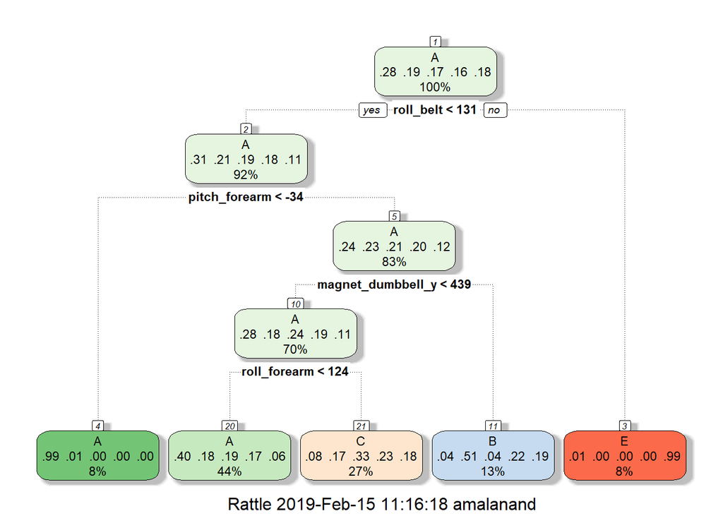

```r
controlCT <- trainControl(method="cv", 5)
modelCT <- train(classe~., data=trainDataFinal, method="rpart", trControl=controlCT)
fancyRpartPlot(modelCT$finalModel)
```

Checking performance with Validation Data Set

```r
predictCT <- predict(modelCT,newdata=valDataFinal)
confMatCT <- confusionMatrix(predictCT, valDataFinal$classe)
confMatCT
```

```
## Confusion Matrix and Statistics
##
##           Reference
## Prediction    A    B    C    D    E
##          A 1539  474  472  454  160
##          B   19  382   40  178  148
##          C  113  283  514  332  282
##          D    0    0    0    0    0
##          E    3    0    0    0  492
##
## Overall Statistics
##
##                Accuracy : 0.4974
##                  95% CI : (0.4845, 0.5102)
##     No Information Rate : 0.2845
##     P-Value [Acc > NIR] : < 2.2e-16
##
##                   Kappa : 0.3424
##  Mcnemar's Test P-Value : NA
##
## Statistics by Class:
##
##                      Class: A Class: B Class: C Class: D Class: E
## Sensitivity            0.9194  0.33538  0.50097   0.0000  0.45471
## Specificity            0.6295  0.91888  0.79214   1.0000  0.99938
## Pos Pred Value         0.4966  0.49804  0.33727      NaN  0.99394
## Neg Pred Value         0.9515  0.85209  0.88260   0.8362  0.89054
## Prevalence             0.2845  0.19354  0.17434   0.1638  0.18386
## Detection Rate         0.2615  0.06491  0.08734   0.0000  0.08360
## Detection Prevalence   0.5266  0.13033  0.25896   0.0000  0.08411
## Balanced Accuracy      0.7744  0.62713  0.64656   0.5000  0.72704
```

We can see that the accuracy rate of the model is low (0.4974) and not a good model

#### 3.3. Using Random Forest

```r
controlRF <- trainControl(method="cv", 5)
modelRF <- train(classe ~ ., data=trainDataFinal, method="rf", trControl=controlRF, ntree=250, verbose=FALSE)
modelRF$finalModel
```

```
##
## Call:
##  randomForest(x = x, y = y, ntree = 250, mtry = param$mtry, verbose = FALSE)
##                Type of random forest: classification
##                      Number of trees: 250
## No. of variables tried at each split: 2
##
##         OOB estimate of  error rate: 0.75%
## Confusion matrix:
##      A    B    C    D    E  class.error
## A 3903    2    0    0    1 0.0007680492
## B   13 2635   10    0    0 0.0086531226
## C    0   20 2374    2    0 0.0091819699
## D    0    0   46 2205    1 0.0208703375
## E    0    0    2    6 2517 0.0031683168
```

Checking performance with Validation Data Set

```r
predictRF <- predict(modelRF, newdata=valDataFinal)
confMatRF <- confusionMatrix(predictRF, valDataFinal$classe)
confMatRF
```

```
## Confusion Matrix and Statistics
##
##           Reference
## Prediction    A    B    C    D    E
##          A 1673    5    0    0    0
##          B    1 1131    7    0    0
##          C    0    3 1017   18    1
##          D    0    0    2  945    7
##          E    0    0    0    1 1074
##
## Overall Statistics
##
##                Accuracy : 0.9924
##                  95% CI : (0.9898, 0.9944)
##     No Information Rate : 0.2845
##     P-Value [Acc > NIR] : < 2.2e-16
##
##                   Kappa : 0.9903
##  Mcnemar's Test P-Value : NA
##
## Statistics by Class:
##
##                      Class: A Class: B Class: C Class: D Class: E
## Sensitivity            0.9994   0.9930   0.9912   0.9803   0.9926
## Specificity            0.9988   0.9983   0.9955   0.9982   0.9998
## Pos Pred Value         0.9970   0.9930   0.9788   0.9906   0.9991
## Neg Pred Value         0.9998   0.9983   0.9981   0.9961   0.9983
## Prevalence             0.2845   0.1935   0.1743   0.1638   0.1839
## Detection Rate         0.2843   0.1922   0.1728   0.1606   0.1825
## Detection Prevalence   0.2851   0.1935   0.1766   0.1621   0.1827
## Balanced Accuracy      0.9991   0.9956   0.9934   0.9892   0.9962
```

```r
accuracy <- postResample(predictRF, valDataFinal$classe)
accuracy
```

```
##  Accuracy     Kappa
## 0.9923534 0.9903271
```

The accuracy rate using the random forest is very high (Accuracy: 0.9923 )

## 4. Result

The analysis shows that the random forest model is the best model We will then use it to predict the values for the test data set.

```r
FinalFinal <- predict(modelRF,newdata=testDataClean)
FinalFinal
```

```
##  [1] B A B A A E D B A A B C B A E E A B B B
## Levels: A B C D E
```